# Ford Go Bike - 2017

## by Quentin

This data set contains bike trip information of Ford Go Bike in 2017. The bike sharing system was rebranded as Ford go Bike on June 28th and is currently know as Bay Wheels and owned by Lyft. This data set covers bike trips data from end of June 2017, when the system was rebranded as Ford Go Bike, to the end of the year 2017.

### Duration time in minutes

> 75% of users fall into 15 minutes duration trip

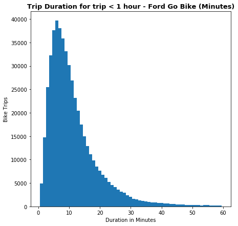

```python
#Visualization
plt.figure(figsize = [7, 7]);
bine = np.arange(0.5, 60, 1);
ticks = [0, 5, 10, 15, 20, 25, 30, 35, 40, 45, 50, 55];

plt.hist(data = df_fgb_clean, x='duration_min', bins = bine);
plt.title("Trip Duration for trip < 1 hour - Ford Go Bike (Minutes)", fontweight=('bold'), fontsize=13);
plt.xlabel('Duration in Minutes');
plt.ylabel('Bike Trips');
```

### User types

> Most users are using the Subscription base model

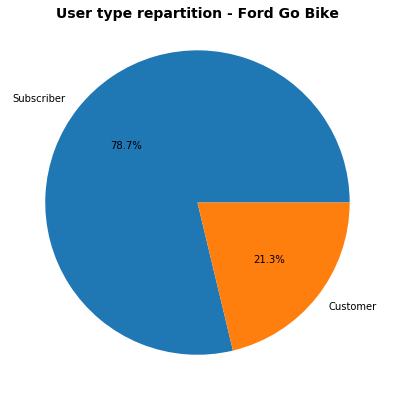

```python
#Let's now look at the repartition of users types within our data set.
plt.figure(figsize = [7, 7]);
plt.pie(user_t, labels= user_t.index, autopct= '%1.1f%%', counterclock= True);
plt.title('User type repartition - Ford Go Bike', fontweight=('bold'), fontsize=14, y=0.97);
```

### Usage by Months

> October was the month with the most trip in the first year of operation as Ford Go Bike

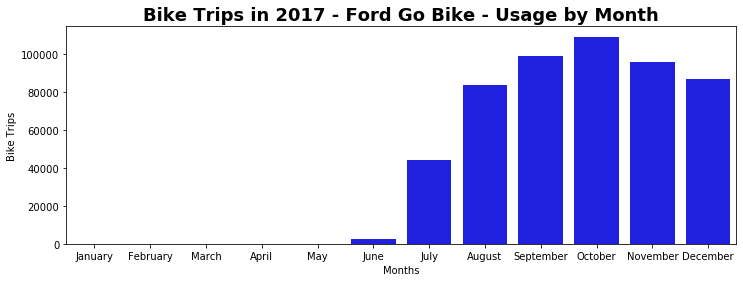

```python
#Let's investigate the distribution of trips on the different months of the year
plt.figure(figsize = [12, 4]);
monthsofy = ['January', 'February', 'March', 'April', 'May', 'June', 'July', 'August',
             'September', 'October', 'November',  'December',];

catgmon = pd.api.types.CategoricalDtype(ordered=True, categories=monthsofy);
df_fgb_vis['start_time_mon'] = df_fgb_vis['start_time_mon'].astype(catgmon);
sb.countplot(data=df_fgb_vis, x='start_time_mon', color='blue');
plt.title("Bike Trips in 2017 - Ford Go Bike - Usage by Month", fontweight=('bold'), fontsize=18);
plt.xlabel('Months');
plt.ylabel('Bike Trips');
```

### Usage by WeekDays

> Ford Go Bikes were mostly used on week working days in 2017

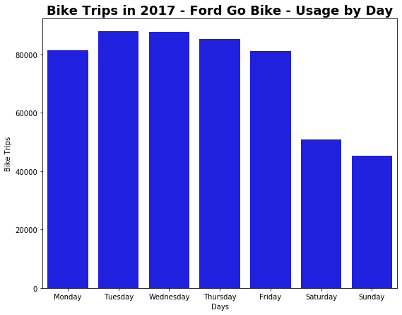

```python
#Let's investigate the distribution of trips depending on the day of the week
plt.figure(figsize = [9, 7])
dayofy = ['Monday', 'Tuesday', 'Wednesday', 'Thursday', 'Friday', 'Saturday', 'Sunday']
catgday = pd.api.types.CategoricalDtype(ordered=True, categories=dayofy);
df_fgb_vis['start_time_wday'] = df_fgb_vis['start_time_wday'].astype(catgday);
sb.countplot(data=df_fgb_vis, x='start_time_wday', color='blue');
plt.title("Bike Trips in 2017 - Ford Go Bike - Usage by Day", fontweight=('bold'), fontsize=18);
plt.xlabel('Days');
plt.ylabel('Bike Trips');
```

### Usage by Hours

> The pic hours for bike trips happened at 8am and 5pm and bikes were mainly used from 7am to 7pm

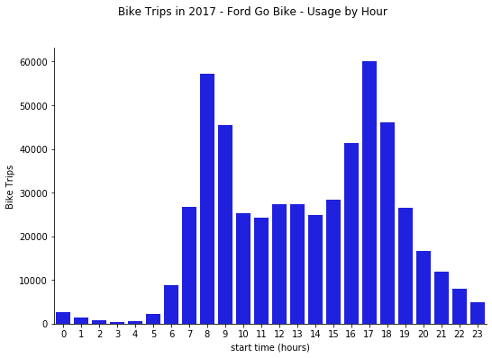

```python
#Visualization of utilization of bikes depending on the starting hour
hour_u = sb.catplot(data = df_fgb_clean, x='start_time_hr', aspect= 1.5, color='blue', kind='count');
hour_u.fig.suptitle('Bike Trips in 2017 - Ford Go Bike - Usage by Hour', y=1.1);
hour_u.set_axis_labels('start time (hours)', 'Bike Trips');
```

### User types and duration (minutes)

> The average duration of trips for Subscriber were close to 10 minutes while Customers had average duration of more than 40minutes in 2017

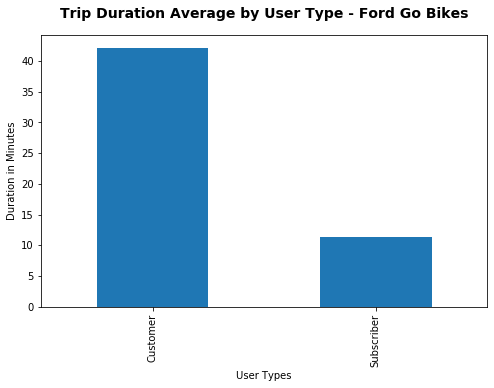

```python
#We will investigate the average duration of trips in minutes between both user types
t_d = df_fgb_clean.groupby('user_type')['duration_min'].mean().plot(kind='bar', figsize=(8,5));
t_d.set_title('Trip Duration Average by User Type - Ford Go Bikes',y=1.04, fontweight=('bold'), fontsize=14);
t_d.set_ylabel('Duration in Minutes');
t_d.set_xlabel('User Types');
```

### User types and usage by days

> Subscriber were much more active on week working days

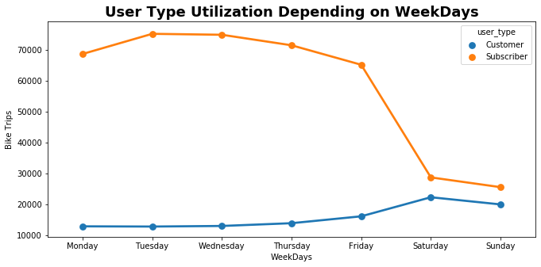

```python
#We will now visualize the utilization of the different user types depending on the day of the week
plt.figure(figsize = [11, 5])

usertbyweek = df_fgb_clean.groupby(['start_time_wday', 'user_type']).size().reset_index()
wday = ['Monday', 'Tuesday', 'Wednesday', 'Thursday', 'Friday', 'Saturday', 'Sunday']

ax = sb.pointplot(data=usertbyweek, x='start_time_wday', hue = 'user_type', order = wday, y=0);
plt.title("User Type Utilization Depending on WeekDays", fontweight=('bold'), fontsize=18);
plt.xlabel('WeekDays');
plt.ylabel('Bike Trips');
```

### User types and usage by months

> Customers highest month was in September, the hottest day of the year.

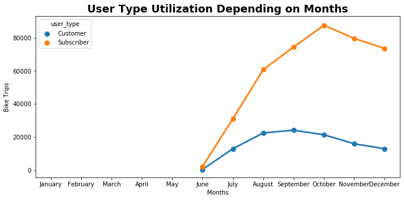

```python
#Visualization of both user types depending on the month of the year
plt.figure(figsize = [11, 5])

usertbymonths = df_fgb_clean.groupby(['start_time_mon', 'user_type']).size().reset_index()
mont = ['January', 'February', 'March', 'April', 'May', 'June', 'July', 'August', 'September',
       'October', 'November', 'December']

ax = sb.pointplot(data=usertbymonths, x='start_time_mon', hue = 'user_type', order = mont, y=0);
plt.title("User Type Utilization Depending on Months", fontweight=('bold'), fontsize=18);
plt.xlabel('Months');
plt.ylabel('Bike Trips');
```

### Trip duration depending on the day of the week for both customer types

> Subscriber were much more constant than customers in regards to the trip duration within their user group and the duration of their utilization across week days.

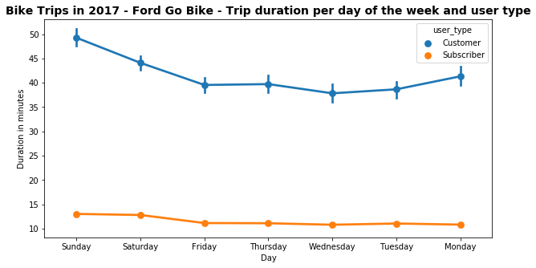

```python
## We will first visualize the duration of trips depending on the day of the week for both customer types
plt.figure(figsize = [10, 5])
sb.pointplot(data=df_fgb_clean, x='start_time_wday', y='duration_min',
             hue='user_type');
plt.title("Bike Trips in 2017 - Ford Go Bike - Trip duration per day of the week and user type", fontweight=('bold'), fontsize=14);
plt.xlabel('Day');
plt.ylabel('Duration in minutes');
```